# Aliens in Cinema

## The Data

The list of films and their release years was downloaded from [this](https://en.wikipedia.org/wiki/List_of_films_featuring_extraterrestrials) Wiki page. Metacritic, IMDB and Rotten Tomatoes scores were obtained using the wonderful [The Open Movie Database](http://www.omdbapi.com/). This is the raw .csv data:

```r
df = read.csv('alien_data.csv')
```

```r
library(knitr)
kable(df[1:10,-1])
```

| Title | Year | Metacritic | Internet.Movie.Database | Rotten.Tomatoes | IMDB.Votes |
| --- | --- | --- | --- | --- | --- |
| 10 Cloverfield Lane | 2016 | 0.76 | 0.72 | 0.90 | 277223 |
| 20 Million Miles to Earth | 1957 | NA | 0.64 | 0.80 | 5923 |
| 2001: A Space Odyssey | 1968 | 0.84 | 0.83 | 0.93 | 574348 |
| Münchhausen | 1943 | NA | 0.85 | NA | 10 |
| 2001: A Space Travesty | 2000 | NA | 0.36 | NA | 11257 |
| 2010: The Year We Make Contact | 1984 | NA | NA | NA | NA |
| The 5th Wave | 2016 | 0.33 | 0.52 | 0.15 | 95416 |
| 6 Days on Earth | 2011 | NA | NA | NA | NA |
| Abbott and Costello Go to Mars | 1953 | NA | 0.61 | 0.33 | 2986 |
| Abraxas, Guardian of the Universe | 1990 | NA | 0.28 | NA | 1609 |

## Score distributions

Lets look at the score distributions for different sites:

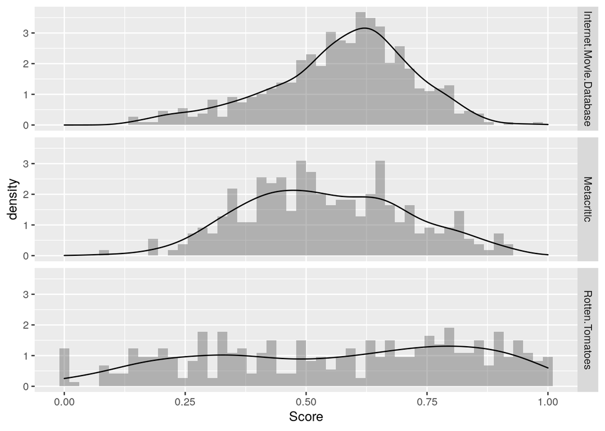

```r
library(tidyverse)
gather(df, Site, Score, c(Metacritic, Internet.Movie.Database, Rotten.Tomatoes)) %>%
  ggplot(mapping=aes(x=Score)) +
  facet_grid(Site ~ .) +
  geom_histogram(aes(y=..density..), bins = 50, alpha=0.4) +
  geom_density() +
  geom_vline(mapping=aes(xintercept=mean(Score)), size=1)
```

Let’s now take a look on the best alien films sorted by the IMDB and Metacritic scores.

### Top 40 Metacritic alien films:

```r
kable(arrange(df, desc(Metacritic))[1:40,-1])
```

| Title | Year | Metacritic | Internet.Movie.Database | Rotten.Tomatoes | IMDB.Votes |
| --- | --- | --- | --- | --- | --- |
| Invasion of the Body Snatchers | 1956 | 0.92 | 0.77 | 0.98 | 42837 |
| E.T. the Extra-Terrestrial | 1982 | 0.91 | 0.78 | 0.98 | 356222 |
| Close Encounters of the Third Kind | 1977 | 0.90 | 0.76 | 0.95 | 176121 |
| Solaris | 1972 | 0.90 | 0.81 | 0.95 | 74798 |
| Star Wars: Episode IV - A New Hope | 1977 | 0.90 | 0.86 | 0.92 | 1181083 |
| Alien | 1979 | 0.89 | 0.84 | 0.98 | 750325 |
| Superman II | 1980 | 0.87 | 0.68 | 0.87 | 94616 |
| The Iron Giant | 1999 | 0.85 | 0.80 | 0.96 | 164805 |
| Star Wars: Episode VIII - The Last Jedi | 2017 | 0.85 | 0.70 | 0.91 | 532835 |
| 2001: A Space Odyssey | 1968 | 0.84 | 0.83 | 0.93 | 574348 |
| Aliens | 1986 | 0.84 | 0.83 | 0.97 | 628300 |
| Avatar | 2009 | 0.83 | 0.78 | 0.82 | 1086714 |
| A Quiet Place | 2018 | 0.82 | 0.75 | 0.95 | 371832 |
| Star Trek | 2009 | 0.82 | 0.79 | 0.94 | 567267 |
| Star Wars: Episode V - The Empire Strikes Back | 1980 | 0.82 | 0.87 | 0.94 | 1109656 |
| Arrival | 2016 | 0.81 | 0.79 | 0.94 | 559093 |
| District 9 | 2009 | 0.81 | 0.79 | 0.90 | 623171 |
| Little Shop of Horrors | 1986 | 0.81 | 0.70 | 0.90 | 61649 |
| The Man Who Fell to Earth | 1976 | 0.81 | 0.67 | 0.83 | 22616 |
| The World’s End | 2013 | 0.81 | 0.70 | 0.89 | 247919 |
| Star Wars: Episode VII - The Force Awakens | 2015 | 0.80 | 0.79 | 0.93 | 833706 |
| Superman | 1978 | 0.80 | 0.73 | 0.94 | 154096 |
| Annihilation | 2018 | 0.79 | 0.69 | 0.88 | 260188 |
| A Shaun the Sheep Movie: Farmageddon | 2019 | 0.79 | 0.69 | 0.96 | 6118 |
| Under the Skin | 2013 | 0.79 | 0.63 | 0.85 | 122282 |
| Avengers: Endgame | 2019 | 0.78 | 0.84 | 0.94 | 694527 |
| The War of the Worlds | 1953 | 0.78 | 0.71 | NA | 31245 |
| Monty Python’s Life of Brian | 1979 | 0.77 | 0.81 | 0.95 | 353546 |
| Village of the Damned | 1960 | 0.77 | 0.73 | 0.92 | 14148 |
| 10 Cloverfield Lane | 2016 | 0.76 | 0.72 | 0.90 | 277223 |
| Guardians of the Galaxy | 2014 | 0.76 | 0.80 | 0.91 | 1007917 |
| Attack the Block | 2011 | 0.75 | 0.66 | 0.90 | 96905 |
| Invasion of the Body Snatchers | 1978 | 0.75 | 0.74 | 0.93 | 49532 |
| Repo Man | 1984 | 0.75 | 0.69 | 0.98 | 32233 |
| Thor: Ragnarok | 2017 | 0.74 | 0.79 | 0.93 | 542938 |
| Lilo & Stitch | 2002 | 0.73 | 0.72 | 0.86 | 160264 |
| The Man Who Wasn’t There | 2001 | 0.73 | 0.75 | 0.81 | 100728 |
| War of the Worlds | 2005 | 0.73 | 0.65 | 0.75 | 403735 |
| Doctor Strange | 2016 | 0.72 | 0.75 | 0.89 | 562696 |
| Star Trek Into Darkness | 2013 | 0.72 | 0.77 | 0.84 | 454690 |

### Top 40 IMDB alien films:

```r
kable(arrange(df, desc(Internet.Movie.Database))[1:40,-1])
```

[output not shown]

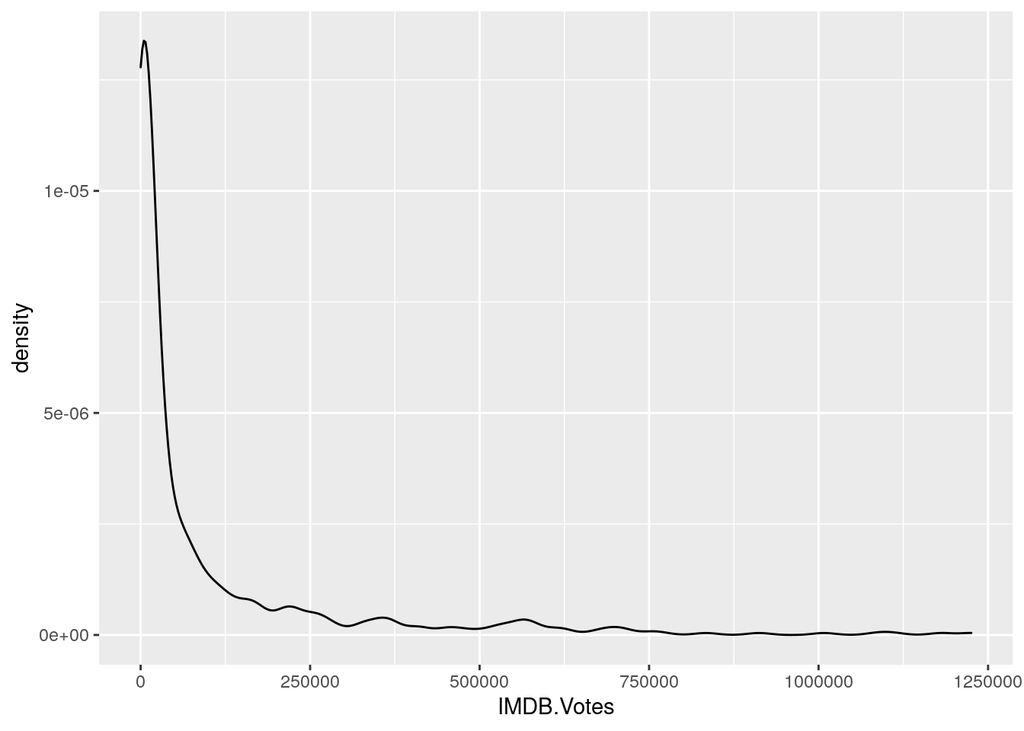

```r
ggplot(data=df, mapping=aes(IMDB.Votes)) +
  geom_density()
```

Let’s now plot the top IMDB and the top Metacritic alien films together. First thing let’s check how many films ecen *are* scored by both sites:

```r
(count(df) - select(df, Metacritic, Internet.Movie.Database) %>% filter(is.na(Metacritic) | is.na(Internet.Movie.Database)) %>% count)$n
```

```
## [1] 269
```

That’s only 47% off all the films, sad! Ok, now let’s do the plotting:

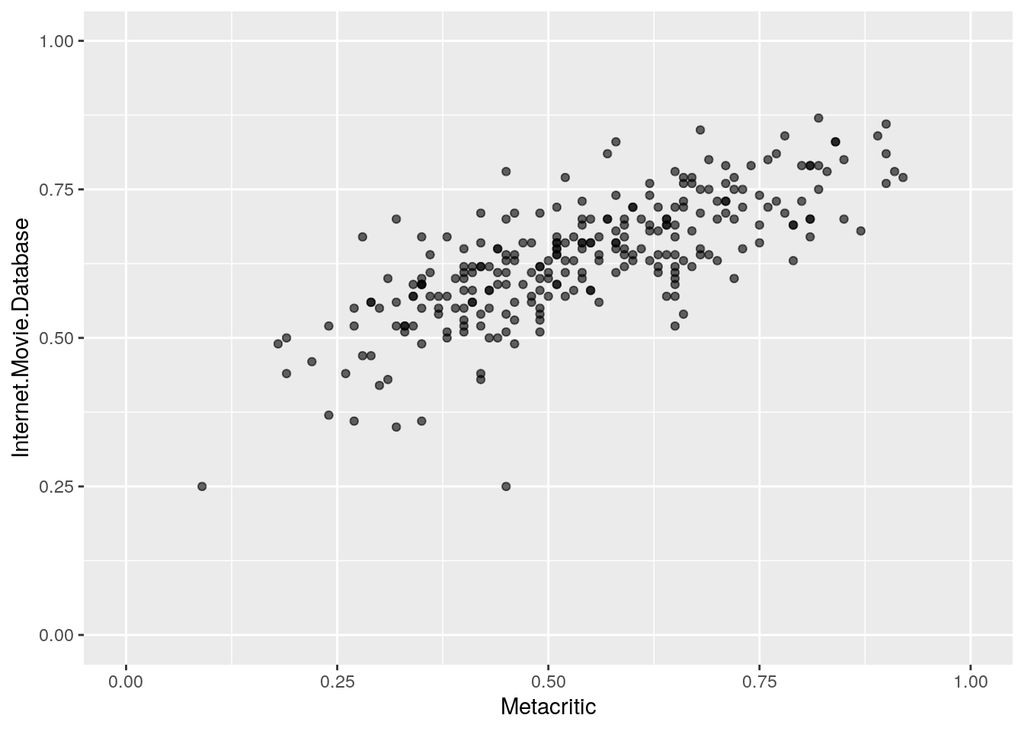

```r
ggplot(data=df, mapping=aes(Metacritic, Internet.Movie.Database)) +
  geom_point(alpha=0.6) +
  xlim(0,1) +
  ylim(0,1)
```

How about coloring points by number of their IMDB votes?

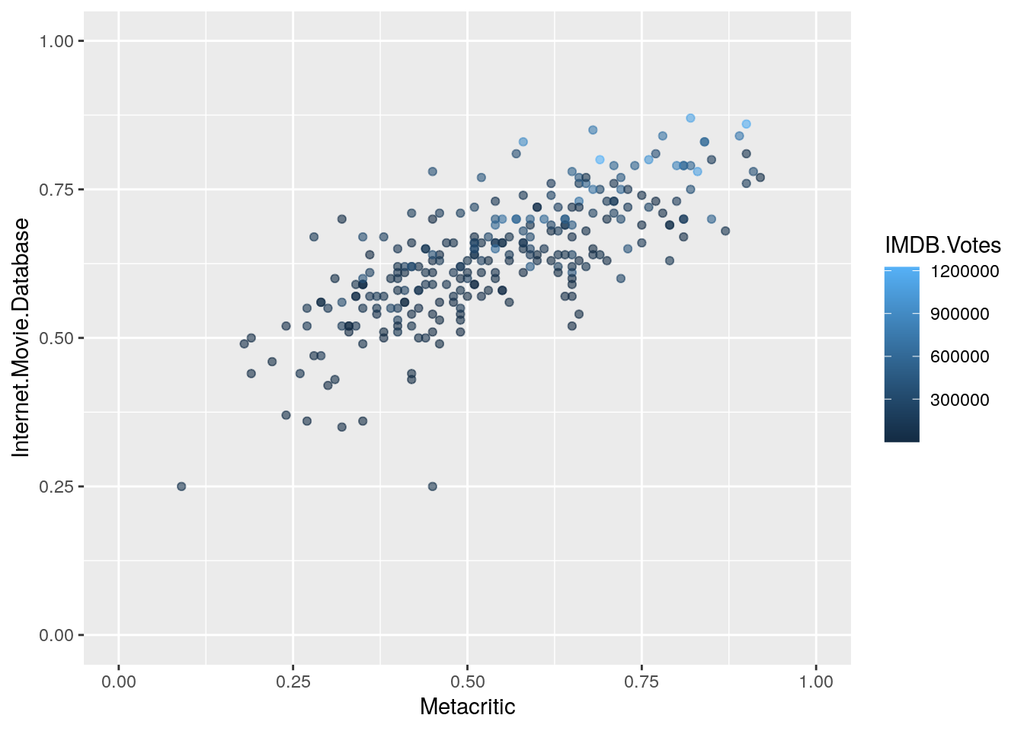

```r
ggplot(data=df, mapping=aes(Metacritic, Internet.Movie.Database, color=IMDB.Votes)) +
  geom_point(alpha=0.6) +
  xlim(0,1) +
  ylim(0,1)
```

Let’s see how rated are the most popular 90th centile films:

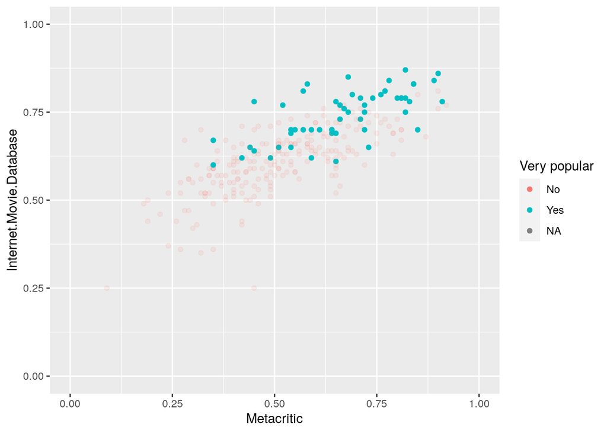

```r
upperVotes = (df %>% summarise(x = quantile(IMDB.Votes, probs = 0.90, na.rm=T)))$x

ggplot(data=df,
       mapping=aes(Metacritic, Internet.Movie.Database,
       color=ifelse(IMDB.Votes > upperVotes, 'Yes', 'No'),
       alpha=ifelse(IMDB.Votes > upperVotes, 1.0, 0.9))) +
  geom_point() +
  xlim(0,1) +
  ylim(0,1) +
  labs(colour = 'Very popular')+
  guides(alpha = FALSE)
```

Clearly, most popular films on IMDB are better rated than less popular films. See how the spread of their ratings is much smaller on the IMDB axis than the Metacritic axis.

Let’s now focus on the top of the top, that is the films that are rated above 0.7 for both Metacritic and IMDB:

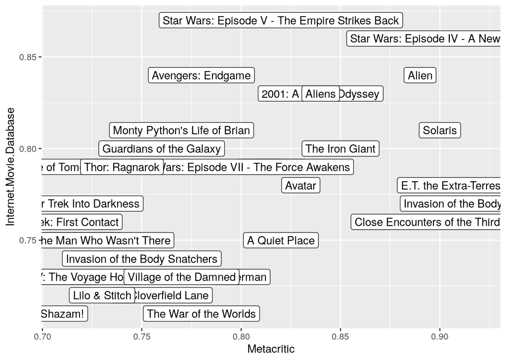

```r
df %>%
  filter(Metacritic > 0.7 & Internet.Movie.Database > 0.7) %>%
  ggplot(mapping=aes(Metacritic, Internet.Movie.Database),
         label=Title) +
    geom_point() +
    geom_label(aes(label=Title))
```